# Scenario Analysis for Temperature Binning Technical Documentation

author: CH  
date: 2/23/2021

# Notes

This notebook will run GCAM reference scenario with 5 different climate sensitivities (ECS) (1.5, 2.0, 3.0, 4.5, 6.0) under 5 different CO2 emission (FFI) reductions (20%, 30%, 50%, 70%, 90%). Total of 6 scenarios (ref + 5) and 5 ECS = 30 scenarios.

The GCAM reference scenario is from [GCAMv5.3](https://github.com/JGCRI/gcam-core/releases/tag/gcam-v5.3). CO2 emissions reductions are linearly extrapolated between 2025 and 2100. Reductions begin the next time step after 2025 (i.e., 2026).

Emissions of all historical gases/aerosols included in Hector from the [GCAM repository](https://github.com/jgcri/gcam-core/input/climate/gcam_emissions.csv)

GCAM reference emissions file (2010-2100) from Pralit Patel (PNNL). Email 2/23/2021 gcam-v5.3-climate-log.csv

Gases/aerosols not include in the future emissions file are set to zero in 2010. They are used to calculate historical temperature change but not future (i.e. CFCs).

# EIA versus GCAM

Compare CO2 emissions from EIA with GCAM reference

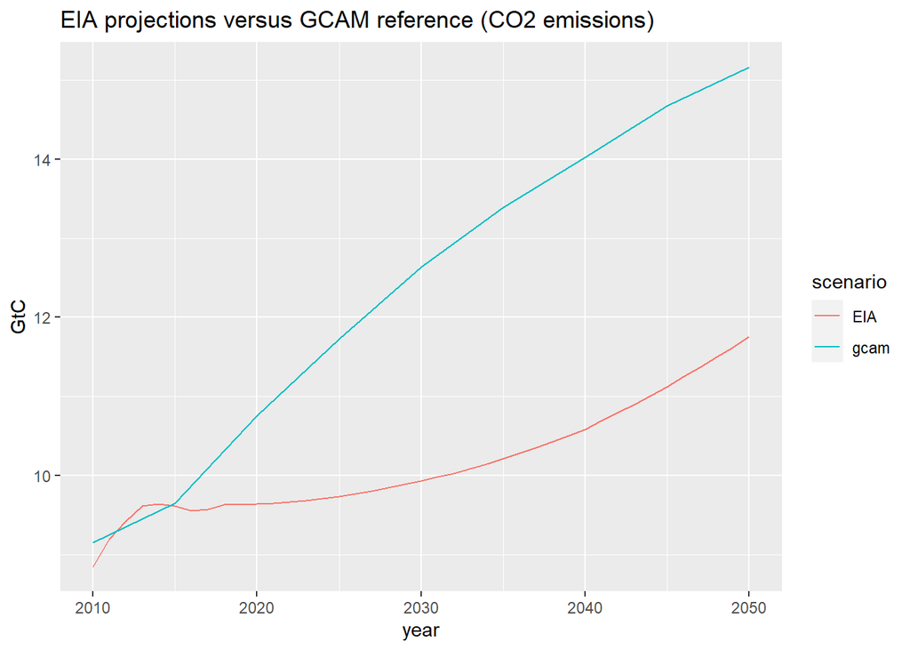

# GCAM reference

Run default Hector core with Reference Scenario

Reference Scenario output - [CO2] (ppmv), Forcing from CO2 (W m-2), Total Forcing (W m-2), Global Mean Temperature (dC)

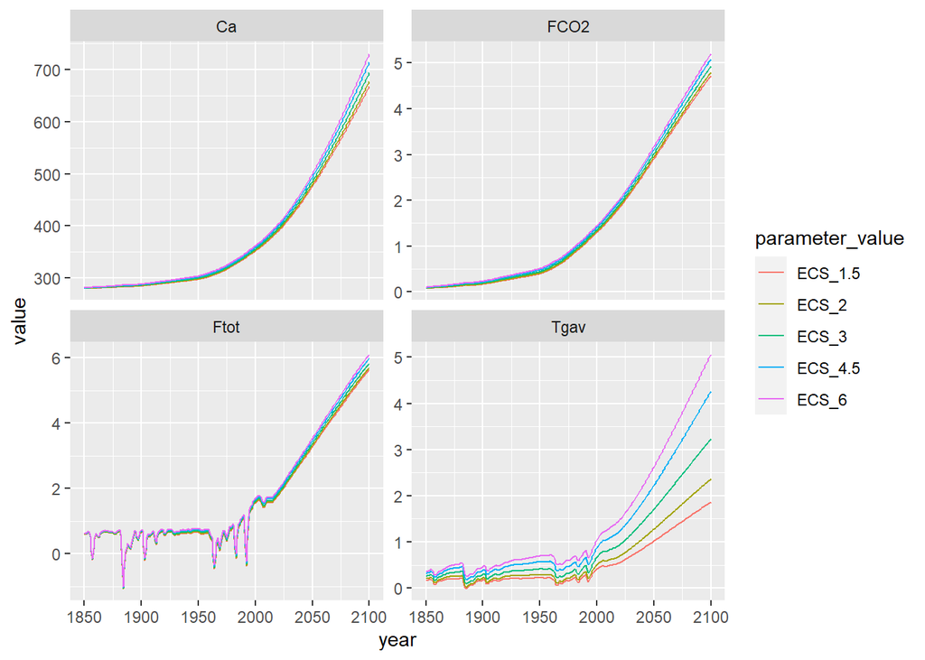

# Percent decrease scenarios

Run Hector with a decrease in FFI_emissions of 20%, 30%, 50%, 70%, 90%

Global Mean Temperature from 1850-2100 with all ECS and scenario combinations

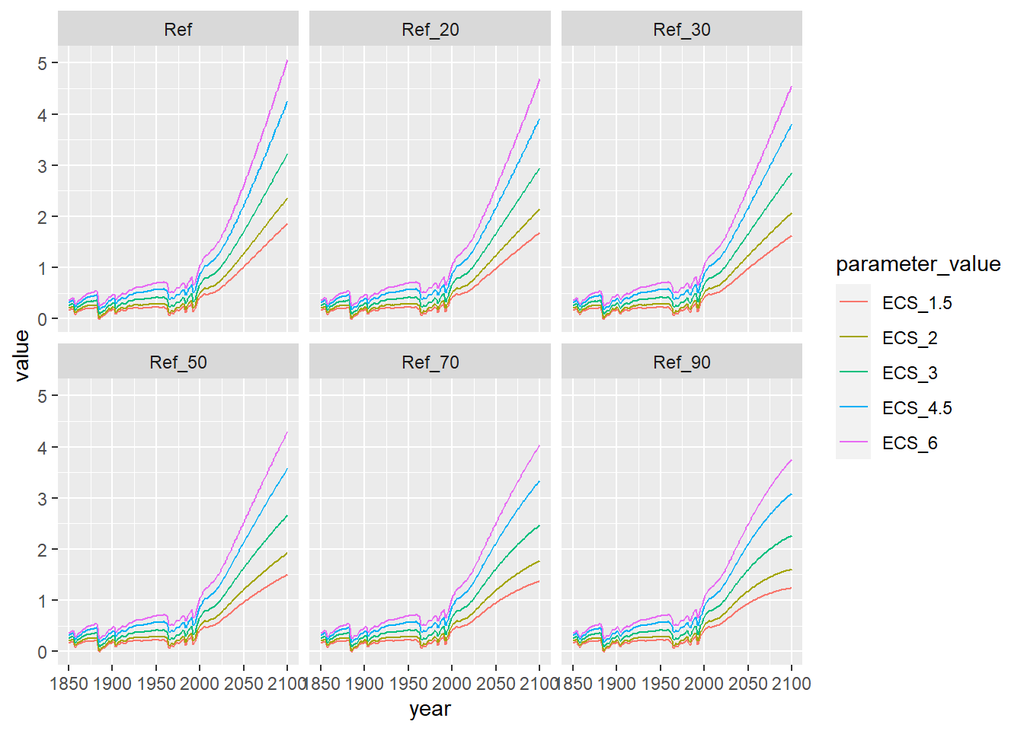

# Table of CO2 emissions

Scenario Emissions

| year | ref | p20 | p30 | p50 | p70 | p90 |
| --- | --- | --- | --- | --- | --- | --- |
| 2025 | 11.72 | 11.72 | 11.72 | 11.72 | 11.72 | 11.72 |
| 2100 | 18.42 | 14.73 | 12.89 | 9.21 | 5.52 | 1.84 |